# spotify_finaltutorial

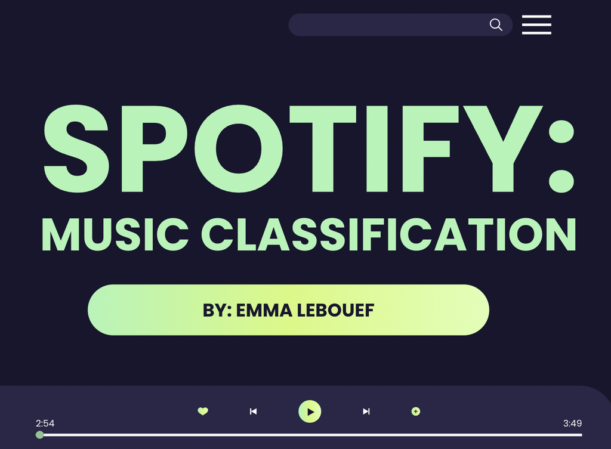

[GITHUB WEBSITE](https://emmalebouef.github.io/spotify/)

## **Establishing a Viable Workspace**

```python
# mounting my google drive
from google.colab import drive
drive.mount('/content/drive')
# changing the directory to my folder designated for this project
%cd /content/drive/My Drive/TU/SEMESTERS/f2023/datascience
```

```
[Errno 2] No such file or directory: '/content/drive/My Drive/TU/SEMESTERS/f2023/datascience'
/content
```

```python
# importing important packages I will need
import pandas as pd
import numpy as np
import seaborn as sns
import matplotlib.pyplot as plt
```

## **QUESTIONS TO BE ANSWERED**

*For this project I want to explore if there is a way to build a recommendation system for a given consumer profile. The recommendation system will output a list of ten songs that it believes the user will enjoy. These songs will be based on a variety of ML models and techniques. Firstly, I will utilize a dataset of over 20k songs with multiple genre labels to merge labels onto a dataset of 1.2 million songs. Based on track similarity, I will build a KNN model that output the five most common sub-genres based on the song's N nearest neighbors. From these genre-typing, I will link different consumer profiles and their reported genre of choice with possible playlists of interest.*

- Potential Challenges:
  - Currently, I do not believe that I have sufficeint consumer data to link favorite genre types between the models.
  - Additionally, the length and detail between the genre types in two of my datasets is not coherent. I will need to find a way to bridge the gap between the detail assigned to each genre.

## **COLLABORATION PLAN**

- I will be working by myself for this project. My current goals are to spend 1-2 hours in non-deadline weeks working towards the completion of this project. Additionally, I want to regularly attend office hours to see if there are areas of my code that I can optimize or models that would more effeciently achieve my goals.

## **WHAT DATA WILL I USE?**

*All of the data that I downloaded was from Kaggle and there was no importing or cleaning issues. For the most part, all dataframes also had very little nan values.*

*The [dataset](https://www.kaggle.com/datasets/rodolfofigueroa/spotify-12m-songs) below contains information on a unique track in Spotify. There are over 1.2 million tracks represented. For every track a series of features are recorded. These features can range from tempo to the amount of accosticness. This dataset could be used to predict any one of the feature variables based on the other reported feature variables. Additionally, depending on computing power, you could build a classification model that clusters songs based on their features. Thus creating your own genres based on the most similar songs*

```python
track_features = pd.read_csv('//content/drive/MyDrive/TU/SEMESTERS/f2023/data science/tracks_features.csv')
# the ids were alphanumeric and meaningless, will create numeric ids later
track_features = track_features.drop(columns = {'id', 'album_id', 'artist_ids'})
track_features.head()
```

|  | name | album | artists | track_number | disc_number | explicit | danceability | energy | key | loudness | ... | speechiness | acousticness | instrumentalness | liveness | valence | tempo | duration_ms | time_signature | year | release_date |
| --- | --- | --- | --- | --- | --- | --- | --- | --- | --- | --- | --- | --- | --- | --- | --- | --- | --- | --- | --- | --- | --- |
| 0 | Testify | The Battle Of Los Angeles | ['Rage Against The Machine'] | 1 | 1 | False | 0.470 | 0.978 | 7 | -5.399 | ... | 0.0727 | 0.02610 | 0.000011 | 0.3560 | 0.503 | 117.906 | 210133 | 4.0 | 1999 | 1999-11-02 |
| 1 | Guerrilla Radio | The Battle Of Los Angeles | ['Rage Against The Machine'] | 2 | 1 | True | 0.599 | 0.957 | 11 | -5.764 | ... | 0.1880 | 0.01290 | 0.000071 | 0.1550 | 0.489 | 103.680 | 206200 | 4.0 | 1999 | 1999-11-02 |
| 2 | Calm Like a Bomb | The Battle Of Los Angeles | ['Rage Against The Machine'] | 3 | 1 | False | 0.315 | 0.970 | 7 | -5.424 | ... | 0.4830 | 0.02340 | 0.000002 | 0.1220 | 0.370 | 149.749 | 298893 | 4.0 | 1999 | 1999-11-02 |
| 3 | Mic Check | The Battle Of Los Angeles | ['Rage Against The Machine'] | 4 | 1 | True | 0.440 | 0.967 | 11 | -5.830 | ... | 0.2370 | 0.16300 | 0.000004 | 0.1210 | 0.574 | 96.752 | 213640 | 4.0 | 1999 | 1999-11-02 |
| 4 | Sleep Now In the Fire | The Battle Of Los Angeles | ['Rage Against The Machine'] | 5 | 1 | False | 0.426 | 0.929 | 2 | -6.729 | ... | 0.0701 | 0.00162 | 0.105000 | 0.0789 | 0.539 | 127.059 | 205600 | 4.0 | 1999 | 1999-11-02 |

5 rows × 21 columns

*All dtypes are as expected. Artist, album, and name are all strings. The remaining variables are either integers, booleans, or float values. I manually converted release date to time*

```python
track_features['release_date'] = pd.to_datetime(track_features['release_date'], format='yyyy-mm-dd', errors='coerce')
track_features.dtypes
```

```
name                        object
album                       object
artists                     object
track_number                 int64
disc_number                  int64
explicit                      bool
danceability               float64
energy                     float64
key                          int64
loudness                   float64
mode                         int64
speechiness                float64
acousticness               float64
instrumentalness           float64
liveness                   float64
valence                    float64
tempo                      float64
duration_ms                  int64
time_signature             float64
year                         int64
release_date        datetime64[ns]
dtype: object
```

### **MULTI GENRE MUSIC**

*The [dataset](https://www.kaggle.com/datasets/siropo/spotify-multigenre-playlists-data/) below is very similar to the other one, it contains information on a unique track in Spotify. However, there is also information about the genres Spotify has labeled it as. There are over 20k tracks represented. For every track a series of features are recorded. These features can range from tempo to the amount of accosticness.This dataset could be used to predict genre based on features.*

```python
# IMPORTING EACH OF THE DATASETS FROM MY GOOGLE DRIVE AND ADDING A CATEGORY BASED ON THE DATAFRAME THEY ARE IN
hip_hop = pd.read_csv('//content/drive/MyDrive/TU/SEMESTERS/f2023/data science/hiphop_music_data.csv')
hip_hop['main_cat'] = 'hip hop'

indie = pd.read_csv('//content/drive/MyDrive/TU/SEMESTERS/f2023/data science/indie_alt_music_data.csv')
indie['main_cat'] = 'indie'

metal = pd.read_csv('//content/drive/MyDrive/TU/SEMESTERS/f2023/data science/metal_music_data.csv')
metal['main_cat'] = 'metal'

pop = pd.read_csv('//content/drive/MyDrive/TU/SEMESTERS/f2023/data science/pop_music_data.csv')
pop['main_cat'] = 'pop'

rock = pd.read_csv('//content/drive/MyDrive/TU/SEMESTERS/f2023/data science/rock_music_data.csv')
rock['main_cat'] = 'rock'

## CONCAT EACH FRAME INTO ONE LARGE FRAME
multi_genre = pd.concat([hip_hop, indie, metal, pop, rock], ignore_index= True)
# DROPPING UNECESSARY COLUMNS
multi_genre = multi_genre.drop(columns = {
       'id', 'uri', 'track_href', 'analysis_url',
       'time_signature'})
multi_genre.head()
```

|  | Artist Name | Track Name | Popularity | Genres | Playlist | danceability | energy | key | loudness | mode | speechiness | acousticness | instrumentalness | liveness | valence | tempo | duration_ms | main_cat |
| --- | --- | --- | --- | --- | --- | --- | --- | --- | --- | --- | --- | --- | --- | --- | --- | --- | --- | --- |
| 0 | 21 Savage | Spiral | 63 | ['atl hip hop', 'rap', 'trap'] | No Cap | 0.814 | 0.659 | 2 | -4.475 | 1 | 0.0829 | 0.001550 | 0.025100 | 0.5680 | 0.1300 | 88.506 | 171527 | hip hop |
| 1 | VIC MENSA | SHELTER ft Wyclef Jean, ft Chance The Rapper | 55 | ['chicago rap', 'conscious hip hop', 'hip hop'... | Mellow Bars | 0.664 | 0.660 | 0 | -5.284 | 1 | 0.2910 | 0.181000 | 0.000002 | 0.1900 | 0.4700 | 90.106 | 261467 | hip hop |
| 2 | Pooh Shiesty | Welcome To The Riches (feat. Lil Baby) | 0 | ['memphis hip hop', 'rap', 'southern hip hop',... | No Cap | 0.842 | 0.400 | 11 | -11.308 | 0 | 0.4860 | 0.045700 | 0.000000 | 0.1720 | 0.2050 | 130.018 | 192052 | hip hop |
| 3 | Athletic Progression | Stepney Tale | 37 | ['aarhus indie', 'danish modern jazz', 'jazz r... | Jazz Rap | 0.632 | 0.800 | 5 | -7.227 | 0 | 0.2340 | 0.547000 | 0.000000 | 0.1470 | 0.4960 | 92.757 | 209833 | hip hop |
| 4 | Ghetts | Fire and Brimstone | 46 | ['grime', 'uk alternative hip hop', 'uk hip hop'] | Grime Shutdown | 0.846 | 0.511 | 1 | -8.116 | 1 | 0.2630 | 0.037500 | 0.000005 | 0.1470 | 0.3460 | 136.964 | 190773 | hip hop |
| ... | ... | ... | ... | ... | ... | ... | ... | ... | ... | ... | ... | ... | ... | ... | ... | ... | ... | ... |
| 22537 | blink-182 | I Miss You | 0 | ['pop punk', 'punk', 'socal pop punk'] | 00s Rock Anthems | 0.652 | 0.766 | 11 | -6.481 | 1 | 0.0345 | 0.000761 | 0.000006 | 0.0739 | 0.6410 | 110.011 | 227813 | rock |
| 22538 | Beloved | Failure On My Lips | 37 | [] | 2000s Screamo | 0.189 | 0.972 | 2 | -2.834 | 0 | 0.0931 | 0.000011 | 0.009400 | 0.2270 | 0.2140 | 172.049 | 276333 | rock |
| 22539 | Saint Louis | Carry Me Away | 35 | [] | Rocktronic | 0.286 | 0.882 | 7 | -2.362 | 1 | 0.0390 | 0.004350 | 0.040600 | 0.1070 | 0.0438 | 139.584 | 183214 | rock |
| 22540 | The Smashing Pumpkins | Disarm - Remastered | 64 | ['alternative metal', 'alternative rock', 'gru... | Rocktail Hour | 0.527 | 0.418 | 4 | -10.205 | 0 | 0.0277 | 0.142000 | 0.781000 | 0.1390 | 0.2170 | 129.517 | 196905 | rock |
| 22541 | Van Der Graaf Generator | A Plague Of Lighthouse Keepers (Medley) - 2005... | 29 | ['art rock', 'experimental', 'jazz fusion', 'n... | Prog Rock Monsters | 0.115 | 0.668 | 0 | -8.363 | 1 | 0.0594 | 0.017800 | 0.000018 | 0.1010 | 0.0728 | 74.857 | 1392667 | rock |

22542 rows × 18 columns

*The appropriate dtypes for the multi-genre dataframe are displayed below*

```python
multi_genre.dtypes
```

```
Artist Name          object
Track Name           object
Popularity            int64
Genres               object
Playlist             object
danceability        float64
energy              float64
key                   int64
loudness            float64
mode                  int64
speechiness         float64
acousticness        float64
instrumentalness    float64
liveness            float64
valence             float64
tempo               float64
duration_ms           int64
main_cat             object
dtype: object
```

*The dataset below represents over 500 Spotify consumers and their observed/ reported behavior. From this dataset we are given demographic information such as age. We can also observe feature interaction within the app as well as prefferred genre/ mood. This data could be used to predict what products should be advertized to specific members or if combined with other datasets, we could build a recommendation system.*

```python
consumer_data = pd.read_excel('/content/drive/MyDrive/TU/SEMESTERS/f2023/data science/consumer_data.xlsx')
consumer_data
```

|  | Age | Gender | spotify_usage_period | spotify_listening_device | spotify_subscription_plan | premium_sub_willingness | preffered_premium_plan | preferred_listening_content | fav_music_genre | music_time_slot | music_Influencial_mood | music_lis_frequency | music_expl_method | music_recc_rating | pod_lis_frequency | fav_pod_genre | preffered_pod_format | pod_host_preference | preffered_pod_duration | pod_variety_satisfaction |
| --- | --- | --- | --- | --- | --- | --- | --- | --- | --- | --- | --- | --- | --- | --- | --- | --- | --- | --- | --- | --- |
| 0 | 20-35 | Female | More than 2 years | Smart speakers or voice assistants | Free (ad-supported) | Yes | Family Plan-Rs 179/month | Podcast | Melody | Night | Sadness or melancholy | leisure time | Playlists | 3 | Daily | Comedy | Interview | Both | Both | Ok |
| 1 | 12-20 | Male | More than 2 years | Computer or laptop | Free (ad-supported) | Yes | Individual Plan- Rs 119/ month | Podcast | Rap | Afternoon | Social gatherings or parties | Workout session | Playlists | 2 | Several times a week | Comedy | Interview | Both | None | Satisfied |
| 2 | 35-60 | Others | 6 months to 1 year | Smart speakers or voice assistants | Free (ad-supported) | Yes | Student Plan-Rs 59/month | Podcast | Pop | Night | Relaxation and stress relief | Study Hours, While Traveling | Playlists | 4 | Once a week | Sports | Interview | None | Both | Satisfied |
| 3 | 20-35 | Female | 1 year to 2 years | Smartphone, Smart speakers or voice assistants | Free (ad-supported) | No | None | Music | Melody | Night | Relaxation and stress relief, Social gathering... | Office hours, Workout session, leisure time | recommendations, Playlists | 4 | Never | None | None | None | None | Ok |
| 4 | 20-35 | Female | 1 year to 2 years | Smartphone | Free (ad-supported) | No | None | Music | Melody | Night | Relaxation and stress relief | leisure time | recommendations, Playlists | 4 | Rarely | Lifestyle and Health | Story telling | Well known individuals | Both | Ok |
| ... | ... | ... | ... | ... | ... | ... | ... | ... | ... | ... | ... | ... | ... | ... | ... | ... | ... | ... | ... | ... |
| 515 | 20-35 | Female | More than 2 years | Smartphone, Computer or laptop, Wearable devices | Free (ad-supported) | Yes | Student Plan-Rs 59/month | Music | Pop | Morning | Uplifting and motivational, Sadness or melancholy | While Traveling | recommendations | 5 | Rarely | Lifestyle and Health | Conversational | Both | Shorter | Ok |
| 516 | 20-35 | Female | More than 2 years | Smartphone, Computer or laptop | Free (ad-supported) | Yes | Student Plan-Rs 59/month | Music | Pop | Night | Relaxation and stress relief, Uplifting and mo... | While Traveling, Workout session, leisure time | Others | 2 | Rarely | Comedy | Story telling | Both | Shorter | Ok |
| 517 | 20-35 | Female | More than 2 years | Smartphone | Free (ad-supported) | No | Student Plan-Rs 59/month | Music | Pop | Night | Relaxation and stress relief | leisure time | recommendations | 3 | Never | None | Story telling | Both | Shorter | Ok |
| 518 | 20-35 | Female | 6 months to 1 year | Smartphone | Premium (paid subscription) | Yes | Individual Plan- Rs 119/ month | Music | Melody | Night | Relaxation and stress relief, Uplifting and mo... | Workout session, leisure time | recommendations, Others | 2 | Several times a week | Comedy | Conversational | Both | Longer | Satisfied |
| 519 | 20-35 | Female | More than 2 years | Smartphone, Computer or laptop | Premium (paid subscription) | Yes | Student Plan-Rs 59/month | Music | Pop | Night | Relaxation and stress relief, Sadness or melan... | Office hours,Study Hours, While Traveling, lei... | Playlists, Radio | 3 | Never | None | None | None | None | Ok |

520 rows × 20 columns

*This is a dataset that is composed primarily of strings. That is reflected correctly below.*

```python
consumer_data.dtypes
```

```
Age                            object
Gender                         object
spotify_usage_period           object
spotify_listening_device       object
spotify_subscription_plan      object
premium_sub_willingness        object
preffered_premium_plan         object
preferred_listening_content    object
fav_music_genre                object
music_time_slot                object
music_Influencial_mood         object
music_lis_frequency            object
music_expl_method              object
music_recc_rating               int64
pod_lis_frequency              object
fav_pod_genre                  object
preffered_pod_format           object
pod_host_preference            object
preffered_pod_duration         object
pod_variety_satisfaction       object
dtype: object
```

### **MERGING OUR TWO SONG BASED DATASETS**

```python
# finding matches between the 1.2 million songs and the 20k songs with genres
merge = pd.merge(multi_genre, track_features, on = ['danceability', 'energy', 'key', 'loudness', 'mode', 'speechiness',
       'acousticness', 'instrumentalness', 'liveness', 'valence', 'tempo',
       'duration_ms'], how = 'inner')
merge = merge.drop(columns = ['name', 'album', 'artists', 'track_number', 'disc_number', 'time_signature', 'release_date'])
merge = merge.drop_duplicates(subset = ['Artist Name', 'Track Name'])
merge = merge.reset_index()
merge.head()
```

|  | index | Artist Name | Track Name | Popularity | Genres | Playlist | danceability | energy | key | loudness | ... | speechiness | acousticness | instrumentalness | liveness | valence | tempo | duration_ms | main_cat | explicit | year |
| --- | --- | --- | --- | --- | --- | --- | --- | --- | --- | --- | --- | --- | --- | --- | --- | --- | --- | --- | --- | --- | --- |
| 0 | 0 | Busta Rhymes | True Indeed | 42 | ['east coast hip hop', 'hardcore hip hop', 'hi... | Spilled Ink | 0.417 | 0.945 | 2 | -2.639 | ... | 0.3570 | 0.000367 | 0.000000 | 0.2490 | 0.8050 | 177.645 | 113120 | hip hop | True | 2020 |
| 1 | 3 | Jorja Smith | By Any Means | 65 | ['alternative r&b', 'dance pop', 'pop', 'r&b',... | Black Lives Matter | 0.750 | 0.418 | 11 | -10.412 | ... | 0.2440 | 0.149000 | 0.000002 | 0.0857 | 0.4420 | 104.981 | 225631 | hip hop | False | 2020 |
| 2 | 4 | Souls Of Mischief | 93 'Til Infinity | 69 | ['alternative hip hop', 'hardcore hip hop', 'h... | I Love My '90s Hip-Hop | 0.590 | 0.672 | 1 | -11.792 | ... | 0.4120 | 0.125000 | 0.000001 | 0.1470 | 0.6880 | 206.247 | 286440 | hip hop | False | 1993 |
| 3 | 5 | Kevin Gates | Big Gangsta | 80 | ['baton rouge rap', 'rap', 'southern hip hop',... | Get Turnt | 0.879 | 0.574 | 10 | -5.602 | ... | 0.3910 | 0.519000 | 0.000009 | 0.1440 | 0.3460 | 144.911 | 243463 | hip hop | True | 2019 |
| 4 | 10 | Aretha Franklin | Jump to It | 42 | ['adult standards', 'classic soul', 'jazz blue... | Sample School | 0.823 | 0.611 | 8 | -8.899 | ... | 0.1360 | 0.127000 | 0.000004 | 0.2060 | 0.8720 | 119.569 | 401267 | hip hop | False | 1982 |
| ... | ... | ... | ... | ... | ... | ... | ... | ... | ... | ... | ... | ... | ... | ... | ... | ... | ... | ... | ... | ... | ... |
| 573 | 1074 | The Alan Parsons Project | Sirius - Chicago Bulls Theme Song | 62 | ['album rock', 'art rock', 'classic rock', 'me... | 80s Soft Rock | 0.624 | 0.396 | 4 | -15.411 | ... | 0.0340 | 0.064700 | 0.909000 | 0.1130 | 0.0388 | 111.401 | 115280 | rock | False | 1982 |
| 574 | 1075 | Van Halen | (Oh) Pretty Woman - 2015 Remaster | 57 | ['album rock', 'classic rock', 'hard rock', 'm... | Rock School | 0.441 | 0.970 | 1 | -2.100 | ... | 0.0708 | 0.192000 | 0.000002 | 0.3120 | 0.5000 | 128.289 | 172671 | rock | False | 1982 |
| 575 | 1078 | Nothing More | Fade In / Fade Out | 56 | ['alternative metal'] | Rock Ballads | 0.411 | 0.805 | 4 | -5.246 | ... | 0.0418 | 0.008790 | 0.000026 | 0.0819 | 0.2380 | 83.479 | 364907 | rock | False | 2017 |
| 576 | 1079 | The Edgar Winter Group | Frankenstein | 47 | ['album rock', 'blues rock', 'classic rock', '... | Prog Rock Monsters | 0.628 | 0.669 | 2 | -14.636 | ... | 0.0932 | 0.090100 | 0.898000 | 0.2370 | 0.5000 | 96.152 | 284293 | rock | False | 1972 |
| 577 | 1080 | Ratt | Givin' Yourself Away | 51 | ['album rock', 'glam metal', 'hard rock', 'met... | Power Ballads | 0.594 | 0.752 | 11 | -10.661 | ... | 0.0263 | 0.008470 | 0.001610 | 0.0578 | 0.7360 | 101.582 | 326000 | rock | False | 1990 |

578 rows × 21 columns

*From the two datasets, there are 578 songs that were represented in both frames*

**In the future, I will build a distance matching function because there is potential for one of these variables to be off and there be a mismatch**

```python
# creating a subset of features that are numerical and describe features about the songs
subset = merge[['danceability', 'energy', 'key', 'loudness', 'mode', 'speechiness',
       'acousticness', 'instrumentalness', 'liveness', 'valence', 'tempo']]
```

```python
from sklearn.preprocessing import StandardScaler
## scaling the data
scaler = StandardScaler()
subset = scaler.fit_transform(subset)
```

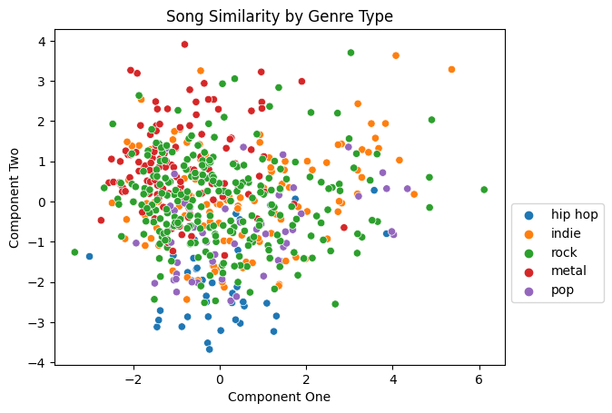

```python
# Graph One: Similarity of songs across multiple vectors
from sklearn.decomposition import PCA
## combining mutlitple columns into two similarity columns
pca = PCA(n_components=2)
X_pca = pca.fit_transform(subset)
# creting a dataframe and merging the main genre type
X_pca = pd.DataFrame(X_pca, columns=["Component One", "Component Two"])
X_pca = pd.merge(merge[['main_cat']], X_pca, left_index = True, right_index = True)
# graphing the similarity features and coloring by main genre type
sns.scatterplot(x="Component One", y="Component Two", hue="main_cat", data=X_pca)
plt.title("Song Similarity by Genre Type")
plt.legend(loc='best', bbox_to_anchor=(1, 0.5))
```

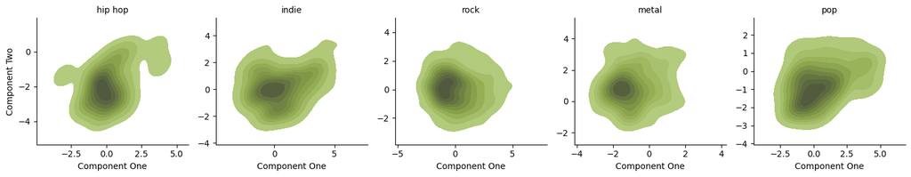

```python
## Graph Two - Showing Neighborhoods Shape by Genre Type
## utilizing facetgrid to plot all five categories from main_cat
neighborhoods = sns.FacetGrid(X_pca, col="main_cat", sharex=False, sharey=False)
## graphing the kernel density to see where each genre roughly lies
neighborhoods.map(sns.kdeplot, "Component One", "Component Two", color="#d5f979ff", fill=True)
# establishing the title as each graph as the name of the column
neighborhoods.set_titles(col_template="{col_name}")
```

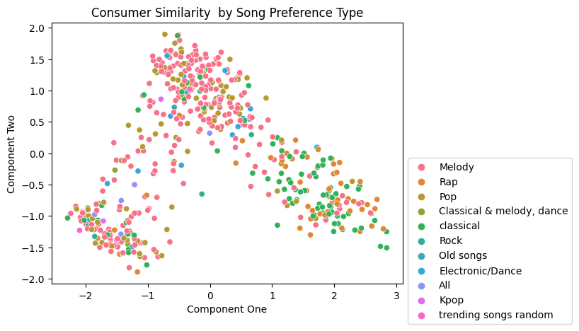

```python
# What about our consumers? Are they similar based on reported favorite song type
## Graph Three
## y is the given favorite music genre
consumer_data_y = consumer_data[['fav_music_genre']]
## building x similaritty based on demographic and behavioral data
consumer_data_x = consumer_data.drop(columns = {'fav_music_genre'})
## converting categorical variables to dummies
consumer_data_x = pd.get_dummies(consumer_data_x, columns=['Age', 'Gender', 'spotify_usage_period', 'spotify_listening_device',
       'spotify_subscription_plan', 'premium_sub_willingness',
       'preffered_premium_plan', 'preferred_listening_content',
       'music_time_slot', 'music_Influencial_mood', 'music_lis_frequency',
       'music_expl_method', 'music_recc_rating', 'pod_lis_frequency',
       'fav_pod_genre', 'preffered_pod_format', 'pod_host_preference',
       'preffered_pod_duration', 'pod_variety_satisfaction'])
## compressing the data into two numerical columns
pca = PCA(n_components=2)
X_pca = pca.fit_transform(consumer_data_x)
# creting a dataframe and merging the favorite genre type
X_pca = pd.DataFrame(X_pca, columns=["Component One", "Component Two"])
X_pca = pd.merge(consumer_data_y[['fav_music_genre']], X_pca, left_index = True, right_index = True)
# graphing the similarity features and coloring by favorite genre type
sns.scatterplot(x="Component One", y="Component Two", hue="fav_music_genre", data=X_pca)
plt.title("Consumer Similarity  by Song Preference Type")
plt.legend(loc='upper left', bbox_to_anchor=(1, 0.5))
```

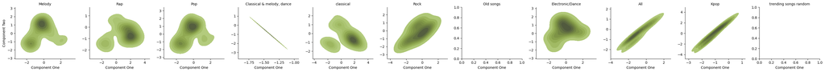

```python
## Graph Four - Showing Neighborhoods Shape by Consumer Type
## utilizing facegrid to plot all five categories from main_cat
neighborhoods = sns.FacetGrid(X_pca, col="fav_music_genre", sharex=False, sharey=False)
## graphing the kernel density to see where each genre roughly lies
neighborhoods.map(sns.kdeplot, "Component One", "Component Two", color="#d5f979ff", fill=True,warn_singular=False)
neighborhoods.set_titles(col_template="{col_name}")
```

```python
## Graph Five:
## is there similarity within playlist?

## limiting to songs that are a part of a playlist that is represented at least 100 times in the dataframe
value_counts = multi_genre['Playlist'].value_counts()
subset = value_counts[value_counts > 100].index
filtered_multi_genre = multi_genre[multi_genre['Playlist'].isin(subset)]
filtered_multi_genre = filtered_multi_genre.reset_index()
```

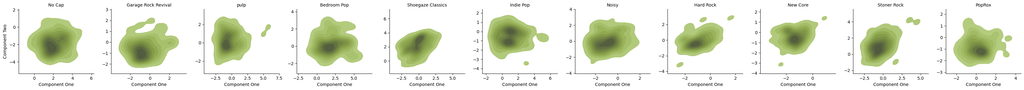

```python
## pulling the x variables based on numerical song features
filtered_multi_genre_x = filtered_multi_genre[['Popularity',
       'danceability', 'energy', 'key', 'loudness', 'mode', 'speechiness',
       'acousticness', 'instrumentalness', 'liveness', 'valence', 'tempo']]
# scaling the data
scaler = StandardScaler()
filtered_multi_genre_x = scaler.fit_transform(filtered_multi_genre_x)
## y is the playlist the songs belong to
filtered_multi_genre_y = filtered_multi_genre[['Playlist']]

## compressing the data into two columns
pca = PCA(n_components=2)
X_pca = pca.fit_transform(filtered_multi_genre_x)
# creting a dataframe and merging the main genre type
X_pca = pd.DataFrame(X_pca, columns=["Component One", "Component Two"])
X_pca = pd.merge(filtered_multi_genre_y[['Playlist']], X_pca, left_index = True, right_index = True)

## graphing the kernel density to see where each playlist roughly lies
neighborhoods = sns.FacetGrid(X_pca, col="Playlist", sharex=False, sharey=False)
neighborhoods.map(sns.kdeplot, "Component One", "Component Two", color="#d5f979ff", fill=True,warn_singular=False)
neighborhoods.set_titles(col_template="{col_name}")
```